# Homework Two

## Question One

We import our data and take a quick look to make sure it looks correct.

```r
library(faraway)
library(car)
head(sat)
```

```
##            expend ratio salary takers verbal math total
## Alabama     4.405  17.2 31.144      8    491  538  1029
## Alaska      8.963  17.6 47.951     47    445  489   934
## Arizona     4.778  19.3 32.175     27    448  496   944
## Arkansas    4.459  17.1 28.934      6    482  523  1005
## California  4.992  24.0 41.078     45    417  485   902
## Colorado    5.443  18.4 34.571     29    462  518   980
```

Now, we create a model with SAT as the response and expend ratio salary and takers as the predictor variables.

```r
model1<-lm(total~expend+salary+ratio+takers, data = sat)

summary(model1)
```

```
##
## Call:
## lm(formula = total ~ expend + salary + ratio + takers, data = sat)
##
## Residuals:
##     Min      1Q  Median      3Q     Max
## -90.531 -20.855  -1.746  15.979  66.571
##
## Coefficients:
##              Estimate Std. Error t value Pr(>|t|)
## (Intercept) 1045.9715    52.8698  19.784  < 2e-16 ***
## expend         4.4626    10.5465   0.423    0.674
## salary         1.6379     2.3872   0.686    0.496
## ratio         -3.6242     3.2154  -1.127    0.266
## takers        -2.9045     0.2313 -12.559 2.61e-16 ***
## ---
## Signif. codes:  0 '***' 0.001 '**' 0.01 '*' 0.05 '.' 0.1 ' ' 1
##
## Residual standard error: 32.7 on 45 degrees of freedom
## Multiple R-squared:  0.8246, Adjusted R-squared:  0.809
## F-statistic: 52.88 on 4 and 45 DF,  p-value: < 2.2e-16
```

### a

We plot the residuals to check for the constant variance assumption.

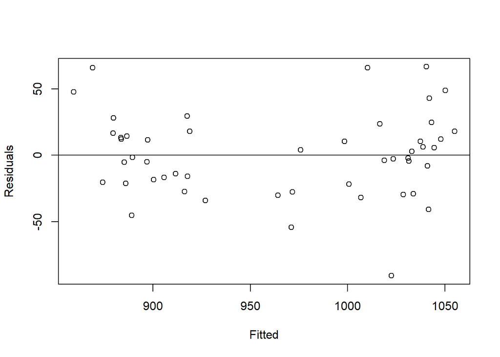

```r
plot(fitted(model1), residuals(model1), xlab="Fitted", ylab="Residuals", abline(h=0))
```

Visually, we see that there is not any unusual patterns that indicate a non-constant variance. Regardless we can run a non-constant variance score test

```r
car::ncvTest(model1)
```

```
## Non-constant Variance Score Test
## Variance formula: ~ fitted.values
## Chisquare = 0.6972119, Df = 1, p = 0.40372
```

We see that the P value is greater that .05 and thus we can say that the variance of the residuals is constant.

### b

We can check the normality assumption by making a qq plot of the residuals

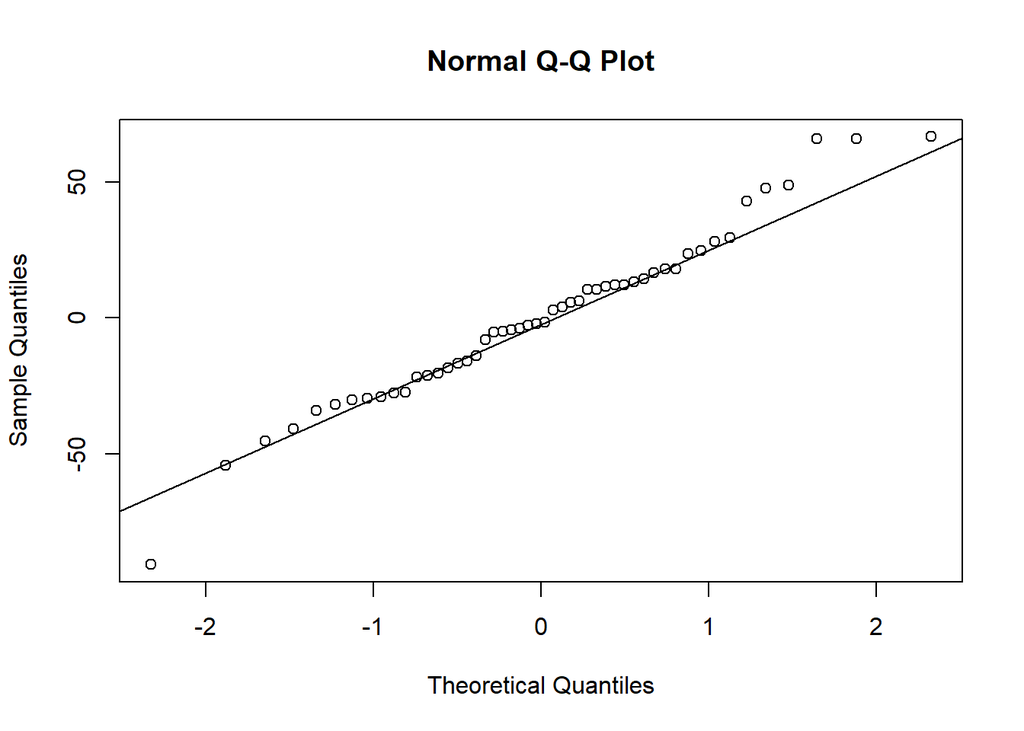

```r
qqnorm(residuals(model1))
qqline(residuals(model1))
```

Visually, we see that there is no cause to doubt that the normality assumption holds. Additionally, we can run a Shapiro test to see if the normality assumption holds.

```r
shapiro.test(residuals(model1))
```

```
##
##  Shapiro-Wilk normality test
##
## data:  residuals(model1)
## W = 0.97691, p-value = 0.4304
```

because of the sufficiently large P value, we can say that the normality assumption holds.

### c

we check the values of the diagonal hat matrix to see the leverage

```r
hat<- hatvalues(model1)
p=length(coefficients(model1))
n=length(fitted(model1))
ratio=p/n
plot(hat, main = 'Levarage plot', ylab = 'levarage', xlab = 'index')
abline(h=c(2,3)*ratio, col="blue", lty=2)
which.max(hat)
```

```
## Utah
##   44
```

```r
which.max(hat[hat!=max(hat)])
```

```
## California
##          5
```

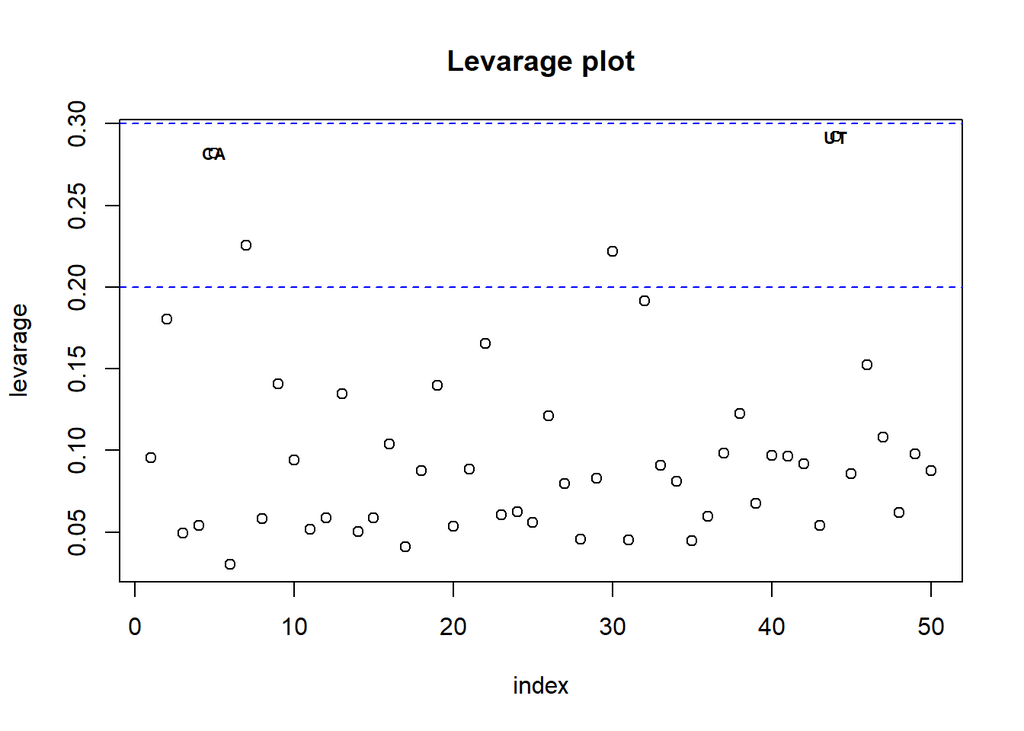

```r
text(44, hat["Utah"], labels="UT", cex=.7, font=2)
text(5,hat["California"], labels="CA", cex=0.7, font=2)
```

we see that california and Utah are levarage points

### d

We now check for out-liers and see that there are none to be found.

```r
car::outlierTest(model1)
```

```
## No Studentized residuals with Bonferroni p < 0.05
## Largest |rstudent|:
##                rstudent unadjusted p-value Bonferroni p
## West Virginia -3.124428          0.0031496      0.15748
```

### e

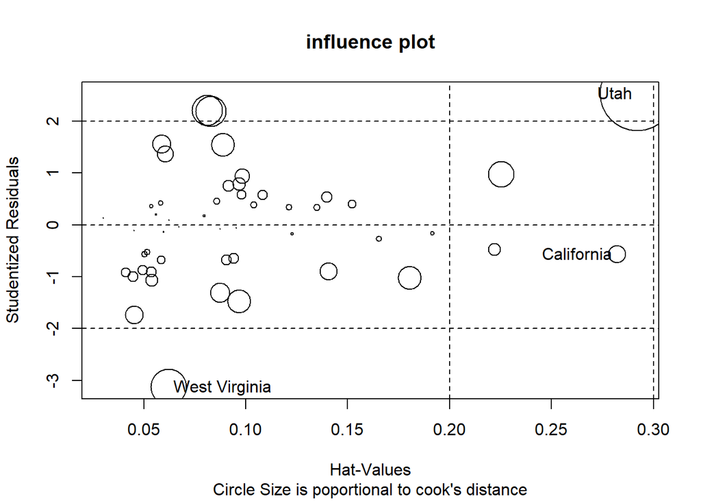

```
##                  StudRes        Hat      CookD
## California    -0.5676458 0.28211791 0.02571304
## Utah           2.5295873 0.29211280 0.47152866
## West Virginia -3.1244283 0.06206536 0.10813954
```

```r
car::influencePlot(model1, id.method="identify", main="influence plot", sub="Circle Size is poportional to cook's distance")
```

### f

We now use R to plot the relationships with the other other predictors and response.

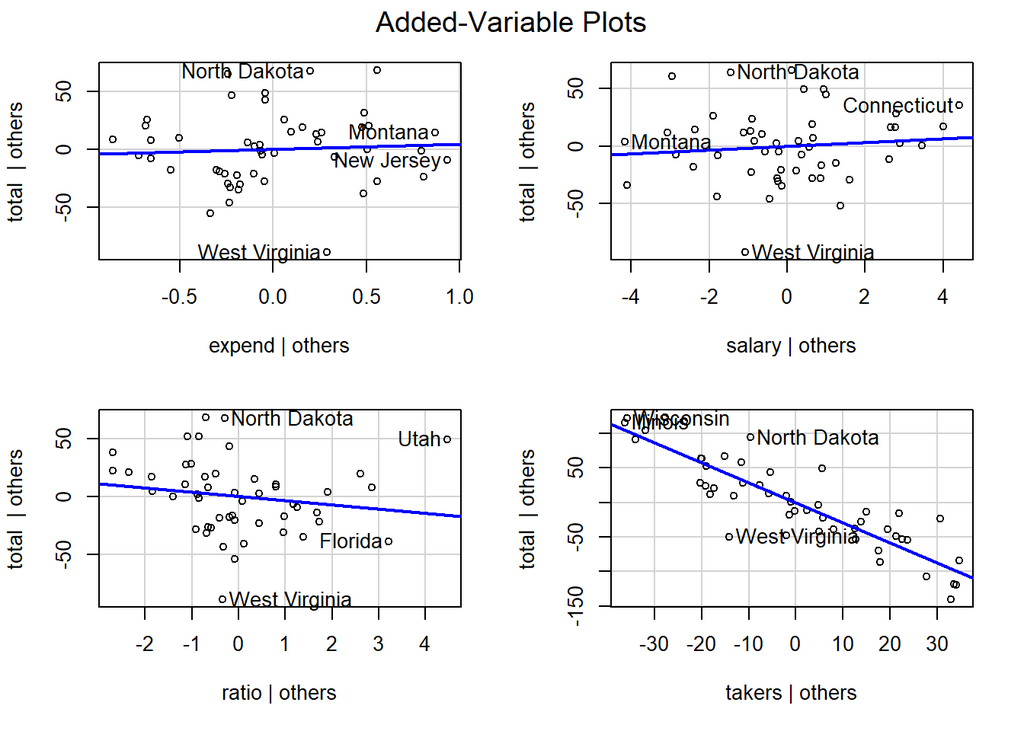

```r
car::avPlots(model1)
```

We see that there are weak positive linear relationships with expend and salary. There are negative relationships with ratio and takers. Ratio however has a weak negative relationship while takers is a strong negative relationship. # Question two

```r
head(prostate)
```

```
##       lcavol lweight age      lbph svi      lcp gleason pgg45     lpsa
## 1 -0.5798185  2.7695  50 -1.386294   0 -1.38629       6     0 -0.43078
## 2 -0.9942523  3.3196  58 -1.386294   0 -1.38629       6     0 -0.16252
## 3 -0.5108256  2.6912  74 -1.386294   0 -1.38629       7    20 -0.16252
## 4 -1.2039728  3.2828  58 -1.386294   0 -1.38629       6     0 -0.16252
## 5  0.7514161  3.4324  62 -1.386294   0 -1.38629       6     0  0.37156
## 6 -1.0498221  3.2288  50 -1.386294   0 -1.38629       6     0  0.76547
```

```r
model2<- lm(lpsa~., data=prostate)

summary(model2)
```

```
##
## Call:
## lm(formula = lpsa ~ ., data = prostate)
##
## Residuals:
##     Min      1Q  Median      3Q     Max
## -1.7331 -0.3713 -0.0170  0.4141  1.6381
##
## Coefficients:
##              Estimate Std. Error t value Pr(>|t|)
## (Intercept)  0.669337   1.296387   0.516  0.60693
## lcavol       0.587022   0.087920   6.677 2.11e-09 ***
## lweight      0.454467   0.170012   2.673  0.00896 **
## age         -0.019637   0.011173  -1.758  0.08229 .
## lbph         0.107054   0.058449   1.832  0.07040 .
## svi          0.766157   0.244309   3.136  0.00233 **
## lcp         -0.105474   0.091013  -1.159  0.24964
## gleason      0.045142   0.157465   0.287  0.77503
## pgg45        0.004525   0.004421   1.024  0.30886
## ---
## Signif. codes:  0 '***' 0.001 '**' 0.01 '*' 0.05 '.' 0.1 ' ' 1
##
## Residual standard error: 0.7084 on 88 degrees of freedom
## Multiple R-squared:  0.6548, Adjusted R-squared:  0.6234
## F-statistic: 20.86 on 8 and 88 DF,  p-value: < 2.2e-16
```

Checking Constance variance assumption

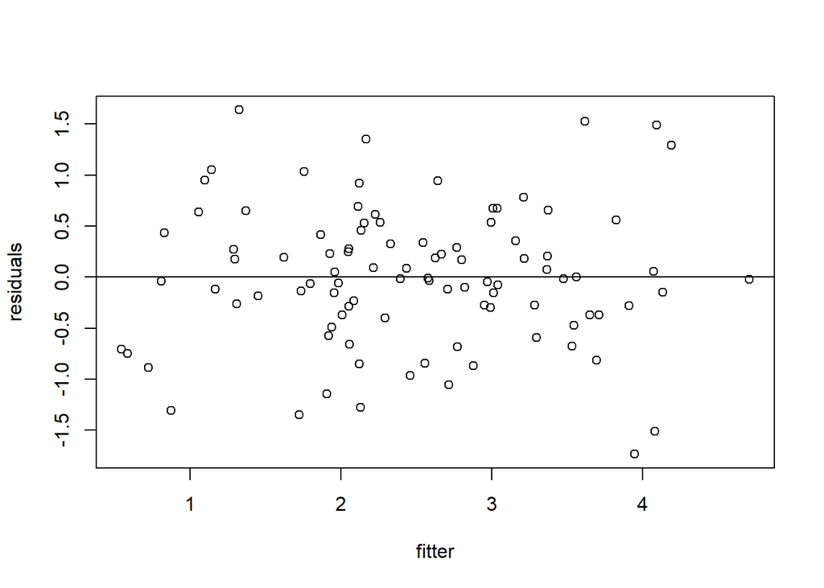

```r
plot(fitted(model2), residuals(model2), xlab="fitter", ylab = "residuals", abline(h=0))
```

```r
ncvTest(model2)
```

```
## Non-constant Variance Score Test
## Variance formula: ~ fitted.values
## Chisquare = 0.2575169, Df = 1, p = 0.61183
```

we see that our P value is large and visually, there is nothing strange. Thus our assumption holds.

#### b

checking the normality assumption.

```r
shapiro.test(residuals(model2))
```

```
##
##  Shapiro-Wilk normality test
##
## data:  residuals(model2)
## W = 0.99113, p-value = 0.7721
```

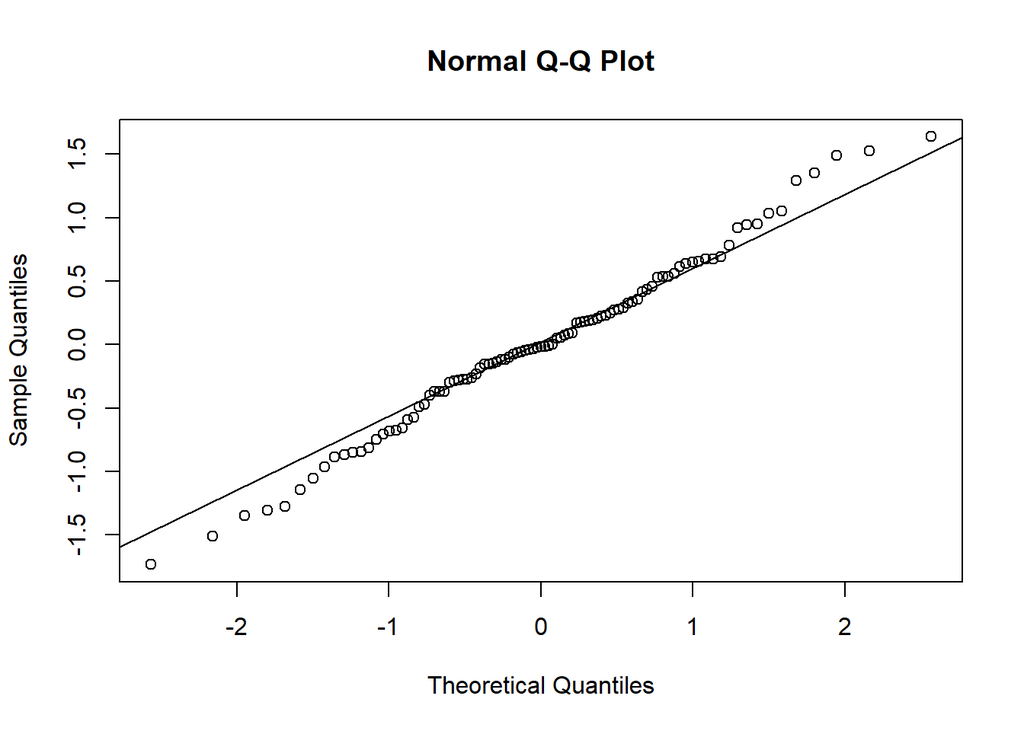

```r
qqnorm(residuals(model2))
qqline(residuals(model2))
```

P value is large, and there is nothing wrong visually, so the normality assumtion holds.

```r
hat <- hatvalues(model2)
p <- length(coefficients(model2))
m<-length(fitted(model2))
ratio<-p/m

plot(hat,main = 'Hat Values')
abline(h=c(2,3)*ratio,col='blue', lty=2)
which.max(hat)
```

```
## 32
## 32
```

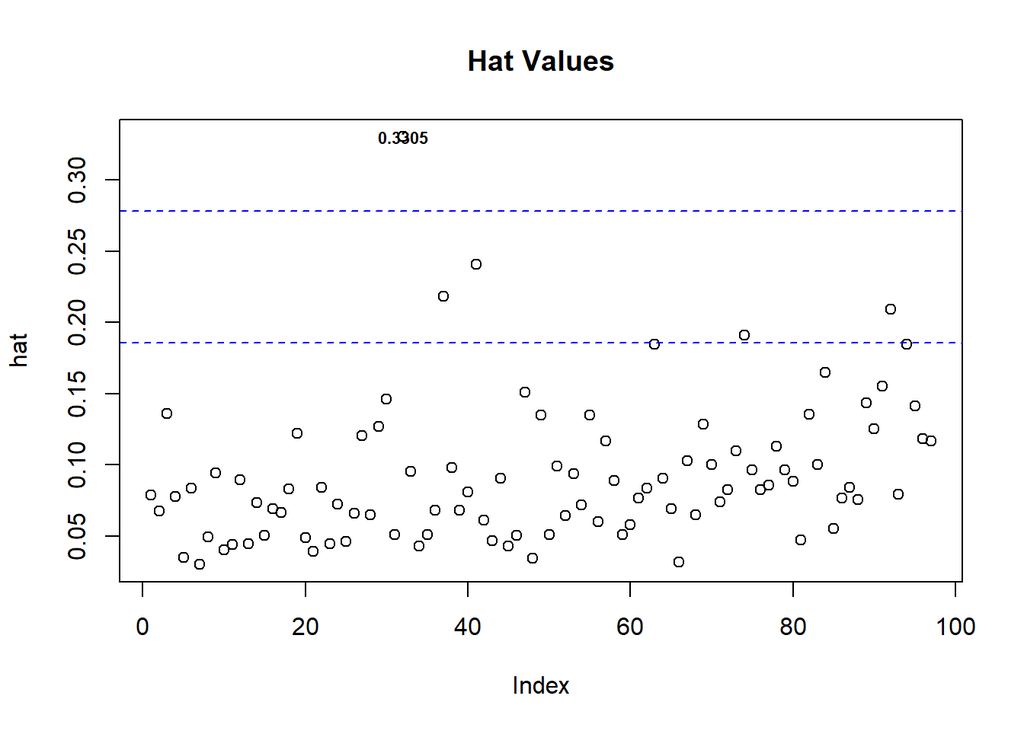

```r
text(32,hat[32], labels=round(hat[32], 4), cex=0.7, font=2)
```

```r
sum(hatvalues(model2))
```

```
## [1] 9
```

and so, visually we see that there is one high leverage value that is affecting the model. which has a value of .3305 and is the 32th observation. the sum of hat values is nine so it checks out.

#### d

checking for outliers

```r
outlierTest(model2)
```

```
## No Studentized residuals with Bonferroni p < 0.05
## Largest |rstudent|:
##    rstudent unadjusted p-value Bonferroni p
## 39 -2.61698            0.01046           NA
```

we see that there are no outliers.

#### e

checking for influence points

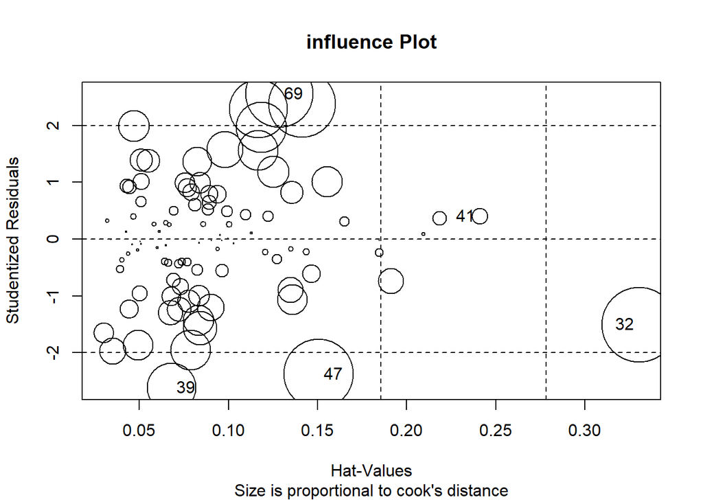

```
##       StudRes        Hat      CookD
## 32 -1.5064788 0.33047574 0.12269771
## 39 -2.6169803 0.06794996 0.05201916
## 41  0.4001244 0.24100789 0.00570304
## 47 -2.3766707 0.15065950 0.10574362
## 69  2.5535302 0.12851989 0.10053751
```

```r
influencePlot(model2, id.method="identify", main="influence Plot", sub="Size is proportional to cook's distance")
```

we see that 32 has the influence observation.

#### f

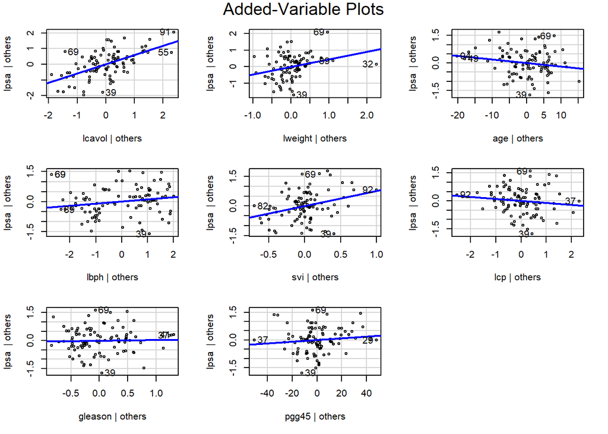

```r
avPlots(model2)
```